# Part 1: Comparing the density of mobile phone cell towers with population: Analysis

This notebook follows along the analysis produced for the publication “Comparing the density of mobile phone cell towers with population” part of the ONS Methodology Working Paper Series

The relationship between official estimates of UK residential and [workday population](https://www.ons.gov.uk/peoplepopulationandcommunity/populationandmigration/populationestimates/articles/theworkdaypopulationofenglandandwales/2013-10-31#data)<sup>1</sup> density and the density of mobile phone cell-towers is investigated using freely available and open-sourced data on cell-tower locations from [OpenCellID](https://opencellid.org/).

```r
# Import Libraries
library(ggplot2)
library(dplyr)
new_theme = theme_get() + theme(axis.text = element_text(size=14),
                                axis.title = element_text(size=14))
theme_set(new_theme)
```

## OpenCellID

The next table illustrates a snapshot of the OpenCellID database updated at 16 January 2017.

Multiple GPS measurements referring to the same antenna are averaged to estimate its location more accurately. The main fields are: mobile technology (radio), mobile country code (mcc)<sup>2</sup>, mobile network (net), cell, longitude (lon), latitude (lat), range, samples (number of measurements), changeable (chg), created (timestamp of first measurement), updated (timestamp of last measurement). More detail on the definitions of these fields are in Appendix A of the publication.

```r
ct = read.table("data/cell_towers2017.csv", header = T, sep = ",", stringsAsFactors = F)
ct
```

| cell | radio | mcc | net | lon | lat | range | samples | changeable | created | updated |
| --- | --- | --- | --- | --- | --- | --- | --- | --- | --- | --- |
| 3564 | GSM | 234 | 55 | -1.891770 | 49.68383 | 6912 | 48 | 1 | 1309376492 | 1309376504 |
| 3505 | GSM | 234 | 55 | -1.904799 | 49.68576 | 7083 | 34 | 1 | 1309376492 | 1309376504 |
| 3628 | GSM | 234 | 55 | -1.846508 | 49.63674 | 24 | 3 | 1 | 1309376492 | 1309376492 |
| 40081 | GSM | 234 | 50 | -1.942688 | 49.70964 | 19160 | 59 | 1 | 1309376502 | 1458857843 |
| 40220 | GSM | 234 | 50 | -1.992018 | 49.70110 | 15596 | 5 | 1 | 1309376502 | 1458857843 |
| 3097 | GSM | 234 | 50 | -1.938819 | 49.69829 | 0 | 1 | 1 | 1309376502 | 1309376502 |
| 3097 | GSM | 234 | 55 | -1.894798 | 49.66684 | 4719 | 2 | 1 | 1309376502 | 1458857843 |
| 3067 | GSM | 234 | 55 | -1.938879 | 49.69835 | 9 | 2 | 1 | 1309376502 | 1309376502 |
| 3006 | GSM | 234 | 55 | -2.005035 | 49.63343 | 43398 | 6 | 1 | 1309376502 | 1458857843 |
| 40081 | GSM | 234 | 55 | -1.946296 | 49.71598 | 2 | 2 | 1 | 1309376504 | 1309376504 |

[output cut: 990 more lines]

The number of cell-towers associated with UK MCCs and listed in the OpenCellID database as per date 16 January 2017 is 1,427,795.

## Analysis at Local Authority District (LAD) level

The latitude and longitude coordinates of 1,382,999 cell-towers were mapped<sup>2</sup> into [2015 UK mainland LAD boundaries](http://geoportal.statistics.gov.uk/datasets?q=LAD%20Boundaries%202015&sort=name), the remaining 44,796 cell-towers being unallocated as they were based in Northern Ireland or their estimated position was in water around the UK coastline.

```r
LAD = read.csv("data/LAD_UK.csv", header = T, sep = ",", stringsAsFactors = F)
LAD = mutate(LAD,
       NP = NUMPOINTS / 1000,
       res = population_2015 / 1000,
       x_1000_res = NUMPOINTS/(population_2015/1000.0))
LAD
```

| LAD15CD | LAD15NM | population_2015 | NUMPOINTS | wd_pop | NP | res | x_1000_res |
| --- | --- | --- | --- | --- | --- | --- | --- |
| E06000001 | Hartlepool | 92493 | 1343 | 88452 | 1.343 | 92.493 | 14.520018 |
| E06000002 | Middlesbrough | 139509 | 1903 | 146734 | 1.903 | 139.509 | 13.640697 |
| E06000003 | Redcar and Cleveland | 135275 | 1327 | 124661 | 1.327 | 135.275 | 9.809647 |
| E06000004 | Stockton-on-Tees | 194803 | 3027 | 190810 | 3.027 | 194.803 | 15.538775 |
| E06000005 | Darlington | 105389 | 1706 | 108660 | 1.706 | 105.389 | 16.187648 |
| E06000006 | Halton | 126528 | 2765 | 125593 | 2.765 | 126.528 | 21.852871 |
| E06000007 | Warrington | 207695 | 6444 | 216407 | 6.444 | 207.695 | 31.026264 |
| E06000008 | Blackburn with Darwen | 146846 | 1825 | 151566 | 1.825 | 146.846 | 12.427986 |
| E06000009 | Blackpool | 139578 | 2047 | 143839 | 2.047 | 139.578 | 14.665635 |
| E06000010 | Kingston upon Hull, City of | 258995 | 2906 | 270010 | 2.906 | 258.995 | 11.220294 |

[output cut: 370 more lines]

Using [2015 mid-year residential population estimates](https://www.ons.gov.uk/peoplepopulationandcommunity/populationandmigration/populationestimates/datasets/populationestimatesforukenglandandwalesscotlandandnorthernireland) for the UK mainland at LAD level, the next Figure shows a scatter plot of the count of cell-towers against residents. It shows that there is a reasonable approximately linear relationship as depicted by a [LOESS](https://en.wikipedia.org/wiki/Local_regression) regression line. The correlation is 0.84.

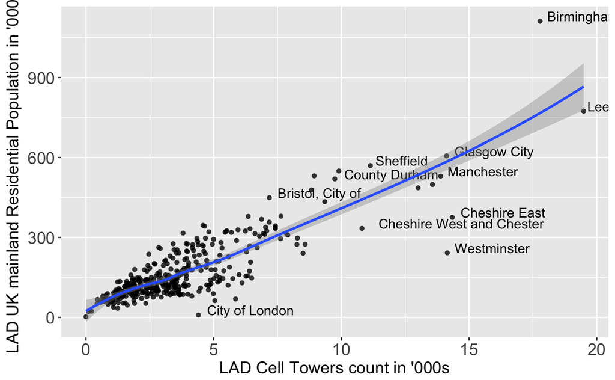

```r
#  Scatter plot of cell tower counts vs. residential population (LADs across UK mainland)
ggplot(LAD, aes(NP, res)) +
  geom_point(size = 2, alpha = 0.8, stroke= 0) +
  geom_text(data=filter(LAD, res > 400 | NP > 10 | LAD15NM == "City of London"), aes(NP, res,label=LAD15NM), check_overlap = TRUE, hjust=-0.1, vjust=0, size = 4)+
  stat_smooth(method = 'loess') +
  xlab("LAD Cell Towers count in '000s") +
  ylab("LAD UK mainland Residential Population in '000s")
```

```r
paste0("Corraletion between cell tower counts and Resiential population at Local Authority District Level: ", round(cor(LAD$NUMPOINTS, LAD$population_2015), 2))
```

```
[1] "Corraletion between cell tower counts and Resiential population at Local Authority District Level: 0.84"
```

Within LADs in England and Wales only, correlation between cell-tower density and residential population is 0.83 and with workday population is 0.86.

```r
LAD_EN = LAD %>%  filter(grepl("E|W", LAD15CD))
LAD_EN
```

| LAD15CD | LAD15NM | population_2015 | NUMPOINTS | wd_pop | NP | res | x_1000_res |
| --- | --- | --- | --- | --- | --- | --- | --- |
| E06000001 | Hartlepool | 92493 | 1343 | 88452 | 1.343 | 92.493 | 14.520018 |
| E06000002 | Middlesbrough | 139509 | 1903 | 146734 | 1.903 | 139.509 | 13.640697 |
| E06000003 | Redcar and Cleveland | 135275 | 1327 | 124661 | 1.327 | 135.275 | 9.809647 |
| E06000004 | Stockton-on-Tees | 194803 | 3027 | 190810 | 3.027 | 194.803 | 15.538775 |
| E06000005 | Darlington | 105389 | 1706 | 108660 | 1.706 | 105.389 | 16.187648 |
| E06000006 | Halton | 126528 | 2765 | 125593 | 2.765 | 126.528 | 21.852871 |
| E06000007 | Warrington | 207695 | 6444 | 216407 | 6.444 | 207.695 | 31.026264 |
| E06000008 | Blackburn with Darwen | 146846 | 1825 | 151566 | 1.825 | 146.846 | 12.427986 |
| E06000009 | Blackpool | 139578 | 2047 | 143839 | 2.047 | 139.578 | 14.665635 |
| E06000010 | Kingston upon Hull, City of | 258995 | 2906 | 270010 | 2.906 | 258.995 | 11.220294 |

[output cut: 338 more lines]

```r
paste0("Corraletion between cell tower counts and Resiential population at Local Authority District Level (England and Wales only): ", round(cor(LAD_EN$NUMPOINTS, LAD_EN$population_2015), 2)) # 0.83
```

```
[1] "Corraletion between cell tower counts and Resiential population at Local Authority District Level (England and Wales only): 0.83"
```

```r
paste0("Corraletion between cell tower counts and WorkDay population at Local Authority District Level (England and Wales only): ", round(cor(LAD_EN$NUMPOINTS, LAD_EN$wd_pop), 2)) # 0.86
```

```
[1] "Corraletion between cell tower counts and WorkDay population at Local Authority District Level (England and Wales only): 0.86"
```

The next Figure shows the distribution across all LADs of the number of cell-towers per 1000 residents. The mean is around 23 cell towers per 1000 residents but there is one outlier having 502 cell towers in the City of London LAD, an area with a much larger workday population compared with its residential population.

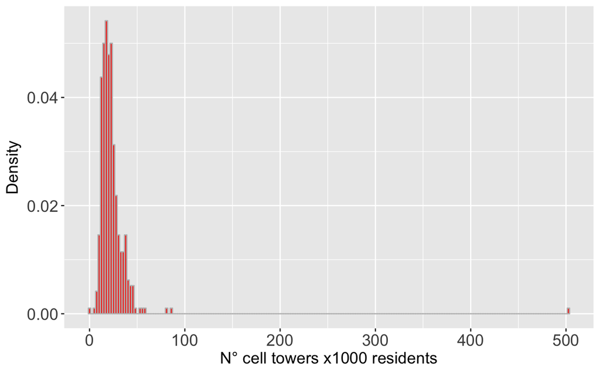

```r
ggplot(LAD, aes(x_1000_res, y=..density..)) +
  geom_histogram(stat = "bin", bins = 200, col="gray",
                 fill="#ef3b2c") +
  ylab("Density") +
  xlab("N° cell towers x1000 residents")
```

```r
paste0("Summary Statistics")
```

```
[1] "Summary Statistics"
```

```r
summary(LAD['x_1000_res'])
```

```
   x_1000_res
 Min.   :  0.00
 1st Qu.: 15.56
 Median : 20.69
 Mean   : 23.64
 3rd Qu.: 26.24
 Max.   :502.51
```

In London and other areas around major urban LADs, it might be expected that the residential population is very different to the [workday population](https://www.ons.gov.uk/peoplepopulationandcommunity/populationandmigration/populationestimates/articles/theworkdaypopulationofenglandandwales/2013-10-31#data). Correlations were therefore run specifically for the 33 Greater London LADs. This revealed that the correlation between residential population and cell tower density in this region is very poor at 0.37 whilst by using workday population the correlation improves up to 0.91.

```r
London_LAD = filter(LAD, grepl('E090000', LAD15CD))
London_LAD
```

| LAD15CD | LAD15NM | population_2015 | NUMPOINTS | wd_pop | NP | res | x_1000_res |
| --- | --- | --- | --- | --- | --- | --- | --- |
| E09000001 | City of London | 8760 | 4402 | 360075 | 4.402 | 8.760 | 502.51142 |
| E09000002 | Barking and Dagenham | 201979 | 3181 | 169117 | 3.181 | 201.979 | 15.74916 |
| E09000003 | Barnet | 379691 | 7636 | 314492 | 7.636 | 379.691 | 20.11109 |
| E09000004 | Bexley | 242142 | 3543 | 196519 | 3.543 | 242.142 | 14.63191 |
| E09000005 | Brent | 324012 | 6239 | 278874 | 6.239 | 324.012 | 19.25546 |
| E09000006 | Bromley | 324857 | 5513 | 269290 | 5.513 | 324.857 | 16.97054 |
| E09000007 | Camden | 241059 | 8500 | 384107 | 8.500 | 241.059 | 35.26108 |
| E09000008 | Croydon | 379031 | 6353 | 310641 | 6.353 | 379.031 | 16.76116 |
| E09000009 | Ealing | 343059 | 7418 | 306007 | 7.418 | 343.059 | 21.62310 |
| E09000010 | Enfield | 328433 | 5953 | 280224 | 5.953 | 328.433 | 18.12546 |

[output cut: 23 more lines]

```r
paste0("Corraletion between cell tower counts and Resiential population at Local Authority District Level (London only): ", round(cor(London_LAD$NUMPOINTS, London_LAD$population_2015), 2)) # 0.37
```

```
[1] "Corraletion between cell tower counts and Resiential population at Local Authority District Level (London only): 0.37"
```

```r
paste0("Corraletion between cell tower counts and WorkDay population at Local Authority District Level (London only): ", round(cor(London_LAD$NUMPOINTS, London_LAD$wd_pop), 2)) # 0.91
```

```
[1] "Corraletion between cell tower counts and WorkDay population at Local Authority District Level (London only): 0.91"
```

## Analysis at Middle Super Output Area (MSOA) level

For all cell-towers in England and Wales (1,262,507 in total), the latitude and longitude coordinates were mapped<sup>2</sup> into [MSOA boundaries](http://geoportal.statistics.gov.uk/datasets?q=MSOA_Boundaries_2011&sort=name).

```r
# Number of cell towers per MSOA vs. number of residents per MSOA. England and Wales
MSOA_EW = read.csv("Data/MSOA_EW_wd_res_ct.csv", header = T, sep = ",", stringsAsFactors = F)
MSOA_EW = mutate(MSOA_EW,
       NP = NUMPOINTS / 1000,
       res = mid_2015_res_pop / 1000,
       wd = wd_pop / 1000)
MSOA_EW
```

| MSOA11NM | MSOA11CD | wd_pop | NUMPOINTS | mid_2015_res_pop | NP | res | wd |
| --- | --- | --- | --- | --- | --- | --- | --- |
| Darlington 001 | E02002559 | 15222 | 733 | 8900 | 0.733 | 8.900 | 15.222 |
| Darlington 002 | E02002560 | 3919 | 36 | 6276 | 0.036 | 6.276 | 3.919 |
| Darlington 003 | E02002561 | 3801 | 41 | 5506 | 0.041 | 5.506 | 3.801 |
| Darlington 004 | E02002562 | 4904 | 37 | 5947 | 0.037 | 5.947 | 4.904 |
| Darlington 005 | E02002563 | 4012 | 56 | 5393 | 0.056 | 5.393 | 4.012 |
| Darlington 006 | E02002564 | 6727 | 30 | 9572 | 0.030 | 9.572 | 6.727 |
| Darlington 007 | E02002565 | 3429 | 29 | 5267 | 0.029 | 5.267 | 3.429 |
| Darlington 008 | E02002566 | 19090 | 120 | 6845 | 0.120 | 6.845 | 19.090 |
| Darlington 009 | E02002567 | 11997 | 122 | 7350 | 0.122 | 7.350 | 11.997 |
| Darlington 010 | E02002568 | 4595 | 37 | 5975 | 0.037 | 5.975 | 4.595 |

[output cut: 990 more lines]

The next Figure shows that there is no linear relationship between cell-tower counts and residential population across MSOAs in England and Wales: the correlation is 0.18.

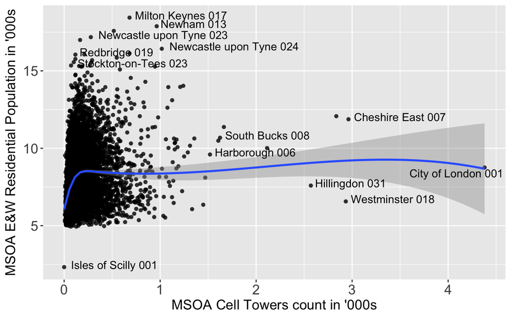

```r
# Number of cell towers per MSOA vs. number of residents per MSOA. England and Wales
ggplot(MSOA_EW, aes(NP, res)) +
  geom_point(size = 2, alpha = 0.8, stroke= 0) +
  stat_smooth(method = "loess") +
  xlab("MSOA Cell Towers count in '000s") +
  ylab("MSOA E&W Residential Population in '000s") +
  geom_text(data=filter(MSOA_EW, res > 15 | (NP > 1.5 & NP < 4)),
            aes(NP, res,label=MSOA11NM), check_overlap = TRUE, hjust=-0.06, vjust=0.2, size = 4)+
  geom_text(data=filter(MSOA_EW, NP > 4),
            aes(NP, res,label=MSOA11NM), check_overlap = TRUE,hjust=0.8, vjust=1.2, size = 4)+
  geom_text(data=filter(MSOA_EW, res < 3),
            aes(NP, res,label=MSOA11NM), check_overlap = TRUE,hjust=-0.08, vjust=0.2, size = 4)
```

```r
paste0("Corraletion between cell tower counts and Resiential population at MSOA Level (England & Wales): ", round(cor(MSOA_EW$NUMPOINTS, MSOA_EW$mid_2015_res_pop),2))
```

```
[1] "Corraletion between cell tower counts and Resiential population at MSOA Level (England & Wales): 0.18"
```

Although workday population is better correlated with cell-tower counts, this correlation is still weak at 0.51.

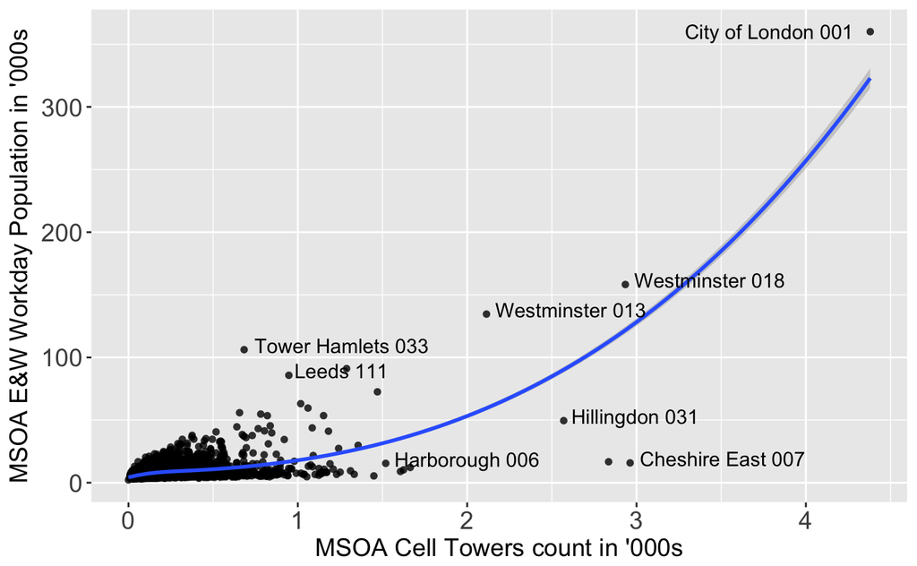

```r
# Number of cell towers per MSOA vs. number of workday population per MSOA. England and Wales
ggplot(MSOA_EW, aes(NP, wd)) +
  geom_point(size = 2, alpha = 0.8, stroke= 0) +
  stat_smooth(method = "loess") +
  xlab("MSOA Cell Towers count in '000s") +
  ylab("MSOA E&W Workday Population in '000s") +
  geom_text(data=filter(MSOA_EW, (wd > 80 & wd < 300) | (NP > 1.5 & NP < 4)),
            aes(NP, wd,label=MSOA11NM), check_overlap = TRUE, hjust=-0.06, vjust=0.2, size = 4)+
  geom_text(data=filter(MSOA_EW, NP > 4),
            aes(NP, wd,label=MSOA11NM), check_overlap = TRUE,hjust=1.1, size = 4)
```

```r
paste0("Corraletion between cell tower counts and WorkDay population at Local Authority District Level (London only): ", round(cor(MSOA_EW$NUMPOINTS, MSOA_EW$wd_pop), 2)) # 0.51
```

```
[1] "Corraletion between cell tower counts and WorkDay population at Local Authority District Level (London only): 0.51"
```

A high population density exists across the whole Greater London area and even though there are still main transport routes, these will similarly run through areas of high population density. Using the workday population for London MSOAs only, the next Figure shows that the correlation with cell towers is a respectable 0.86 compared against a correlation of only 0.15 with 2015 residential population.

```r
# London MSOAs
MSOAs_L = read.table("Lookups/MSOA_London.txt", header = F)
MSOA_London = filter(MSOA_EW, MSOA11CD %in% MSOAs_L$V1)
```

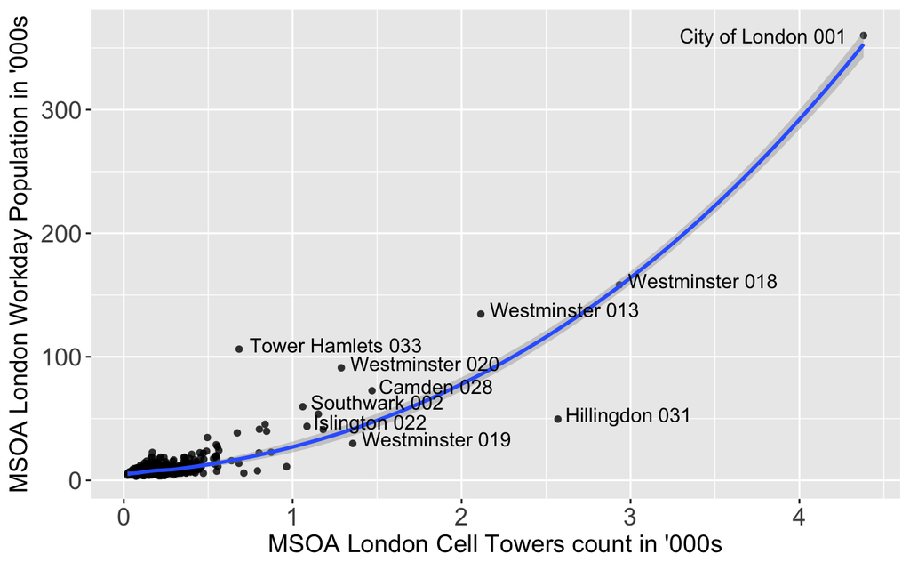

```r
ggplot(MSOA_London, aes(NP, wd)) + geom_point(size = 2, alpha = 0.8, stroke= 0) + stat_smooth(method = "loess") +
  xlab("MSOA London Cell Towers count in '000s") +
  ylab("MSOA London Workday Population in '000s") +
  geom_text(data=subset(MSOA_London, (wd > 100 & wd < 300) | (NP > 1 & NP < 4)),
            aes(NP, wd,label=MSOA11NM),
            check_overlap = TRUE, hjust=-0.06, vjust=0.2, size = 4) +
  geom_text(data=subset(MSOA_London, NP > 4),
            aes(NP, wd,label=MSOA11NM), check_overlap = TRUE,hjust=1.1, size = 4)
```

```r
paste0("Corraletion between cell tower counts and Resiential population at MSOA Level (London only): ", round(cor(MSOA_London$NUMPOINTS, MSOA_London$mid_2015_res_pop), 2)) # 0.15
```

```
[1] "Corraletion between cell tower counts and Resiential population at MSOA Level (London only): 0.15"
```

```r
paste0("Corraletion between cell tower counts and WorkDay population at MSOA Level (London only): ", round(cor(MSOA_London$NUMPOINTS, MSOA_London$wd_pop), 2)) # 0.86
```

```
[1] "Corraletion between cell tower counts and WorkDay population at MSOA Level (London only): 0.86"
```

## Analysis for Lower Super Output Areas (LSOAs) in London only

Since the distortion caused by transport routes may not be as pronounced in London, a more focussed analysis was conducted in this region to see if correlations between cell towers and population density might be good at even smaller geographies, such as LSOA.

```r
LSOA_London = read.csv("Data/LSOA_London_wd_res_ct.csv", header = T, sep = ",", stringsAsFactors = F)
LSOA_London = mutate(LSOA_London,
       NP = NUMPOINTS / 1000,
       res = mid_2015_res_pop / 1000,
       wd = wd_pop / 1000)
LSOA_London
```

| LSOA11CD | LSOA11NM | NUMPOINTS | wd_pop | mid_2015_res_pop | NP | res | wd |
| --- | --- | --- | --- | --- | --- | --- | --- |
| E01000001 | City of London 001A | 272 | 13465 | 1639 | 0.272 | 1.639 | 13.465 |
| E01000002 | City of London 001B | 210 | 30461 | 1412 | 0.210 | 1.412 | 30.461 |
| E01000003 | City of London 001C | 35 | 1561 | 1698 | 0.035 | 1.698 | 1.561 |
| E01000005 | City of London 001E | 259 | 19450 | 1503 | 0.259 | 1.503 | 19.450 |
| E01000006 | Barking and Dagenham 016A | 30 | 1172 | 1868 | 0.030 | 1.868 | 1.172 |
| E01000007 | Barking and Dagenham 015A | 73 | 2405 | 2142 | 0.073 | 2.142 | 2.405 |
| E01000008 | Barking and Dagenham 015B | 36 | 2091 | 1563 | 0.036 | 1.563 | 2.091 |
| E01000009 | Barking and Dagenham 016B | 38 | 1557 | 1775 | 0.038 | 1.775 | 1.557 |
| E01000010 | Barking and Dagenham 015C | 66 | 5709 | 3220 | 0.066 | 3.220 | 5.709 |
| E01000011 | Barking and Dagenham 016C | 6 | 1132 | 1644 | 0.006 | 1.644 | 1.132 |

[output cut: 990 more lines]

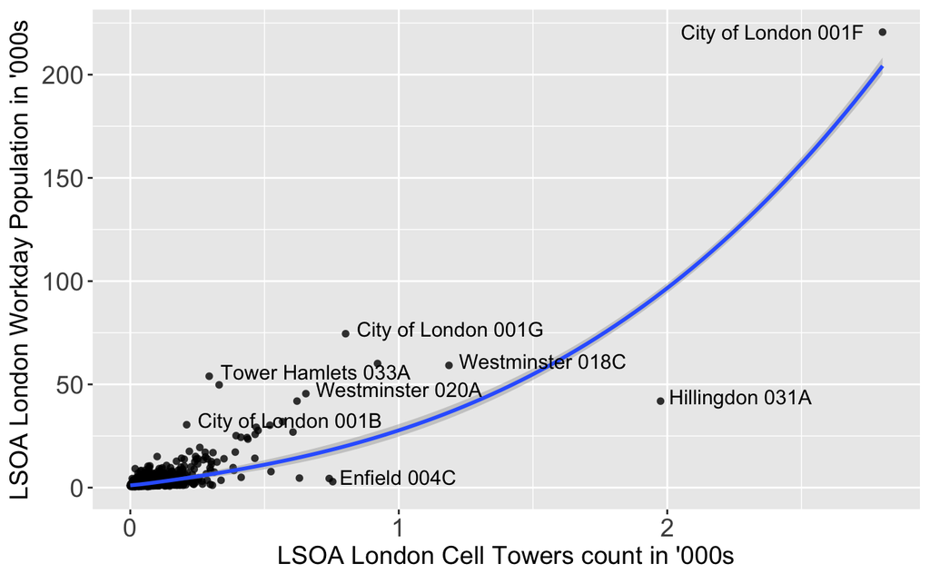

```r
ggplot(LSOA_London, aes(NP, wd)) +
  geom_point(size = 2, alpha = 0.8, stroke= 0) +
  stat_smooth(method = "loess") +
  xlab("LSOA London Cell Towers count in '000s") +
  ylab("LSOA London Workday Population in '000s") +
  geom_text(data=subset(LSOA_London, (wd > 30 & wd < 200) | (NP > 0.5 & NP < 2.5)),
            aes(NP, wd, label=LSOA11NM),
            check_overlap = TRUE,  hjust=-0.06, vjust=0.2, size = 4) +
  geom_text(data=subset(LSOA_London, NP > 2.5),
            aes(NP, wd, label=LSOA11NM), check_overlap = TRUE, hjust=1.1, size = 4)
```

```r
paste0("Corraletion between cell tower counts and Resiential population at LSOA Level (London only): ", round(cor(LSOA_London$NUMPOINTS, LSOA_London$mid_2015_res_pop), 2)) # 0.14
```

```
[1] "Corraletion between cell tower counts and Resiential population at LSOA Level (London only): 0.14"
```

```r
paste0("Corraletion between cell tower counts and WorkDay population at LSOA Level (London only): ", round(cor(LSOA_London$NUMPOINTS, LSOA_London$wd_pop), 2)) # 0.82
```

```
[1] "Corraletion between cell tower counts and WorkDay population at LSOA Level (London only): 0.82"
```

Correlation with cell tower density across London LSOAs remains high at 0.82. This compares with 0.14 for similar correlation with residential population, indicating that cell towers are more likely to be positioned to cater for the expected peak demand for mobile telephony which, in London, are more likely to arise from populations present during the workday.

<sup>1</sup> Based on Census 2011

<sup>2</sup> A [mobile country code (MCC)](https://en.wikipedia.org/wiki/Mobile_country_code?oldformat=true) is used in combination with a mobile network code (MNC) to uniquely identify an MNO. The MCCs associated with the UK are 234 and 235.

<sup>2</sup> All the mapping of cell-towers to the geographical boundaries has been achieved using [QGIS 2.18.2](http://qgis.osgeo.org) Quantum GIS Geographic Information System. Open Source Geospatial Foundation Project.